# North Star Academy Charter School — NJ School Data Almanac – NJ District Profiles

NJ School Data Almanac

North Star Academy Charter School

ESSEX COUNTY · CHARTER DISTRICT · no DFG · 6,812 STUDENTS (2026)

6,812

Students

88.3%

4-yr grad rate

66.2%

Gr 3-8 ELA

21.7%

Chronically absent

*10 things the data says about North Star Academy Charter School. Every figure is computed from New Jersey Department of Education data via the njschooldata package — nothing is estimated. Comparisons use District Factor Group (DFG) peers.*

No. 1 ACHIEVEMENT

## North Star’s Grade 3-8 Math Proficiency Fell From 71% Before COVID to 45% in 2022 — and Has Barely Recovered to 47%

Math proficiency in grades 3-8 dropped 26 points from 2019 to 2022 and has clawed back just over two points in the two years since.

Before the pandemic, North Star’s elementary and middle schoolers were strong in math: 71.1% scored proficient or above on the state NJSLA exam in 2019, up from 65.4% in 2017. Then the floor gave way. By 2022, the share of students in grades 3 through 8 hitting the math bar had collapsed to 45.0% — a drop of 26 percentage points.

The recovery has been faint. The math proficiency rate inched to 46.5% in 2023 and 47.4% in 2024, leaving the network roughly 24 points below its 2019 mark four years after the disruption. The pattern stands in contrast to the network’s high-profile college-prep results, where nearly half of high schoolers pass an AP or IB exam.

English told a milder version of the same story: grade 3-8 ELA proficiency slid from 78.5% in 2019 to 64.0% in 2022 before recovering to 66.2% in 2024. The gulf between the two subjects raises a question the data poses but cannot settle: why has reading climbed back toward two-thirds proficient while math remains stuck in the high 40s?

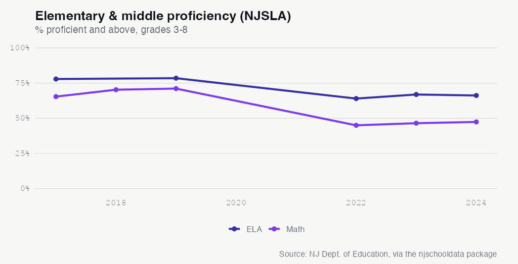

See the underlying data ›

No. 2 EQUITY

## On North Star’s Grade 3-8 English Test, White Students Pass at 80% While Students With Disabilities Pass at 22%

North Star’s overall grade 3-8 English proficiency of 66.2% in 2024 conceals a wide spread underneath it. White students posted the highest rate at 80.0%, followed by students who are not economically disadvantaged at 71.6% and female students at 71.3%. Black students passed at 67.5%, just above the schoolwide average, while Hispanic students passed at 59.8% and male students at 59.0%.

The steepest drops come at the bottom. Students classified as current or former multilingual learners passed at 34.2%, students with disabilities receiving accommodations at 27.8%, and students in special education at 21.7% — a 58-percentage-point gap from the white subgroup at the top. A separate multilingual-learner category registered 18.2% proficient.

These are the students for whom a college-prep model is hardest to deliver, and they are also among North Star’s fastest-growing populations as Hispanic and multilingual-learner enrollment climbs. The data leaves open whether the network’s supports can close a gap this wide for the groups expanding most quickly.

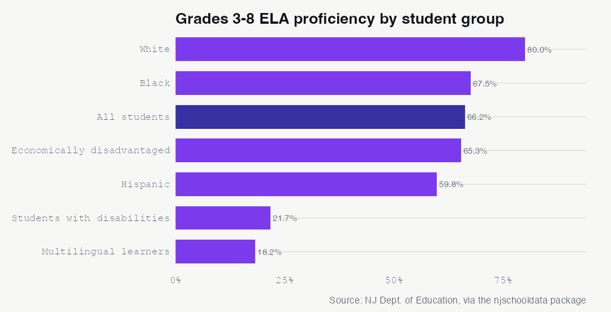

See the underlying data ›

No. 3 ENROLLMENT

## North Star More Than Doubled Its Enrollment in a Decade, Adding 3,409 Students to Reach 6,812

The Newark charter network grew from 3,403 students in 2015 to a record 6,812 in 2026, a 100.2% expansion that continued straight through the pandemic.

Few public schools in New Jersey have grown the way North Star Academy Charter School has. In 2015 the Newark charter network enrolled 3,403 students. By 2026 it enrolled 6,812 — an increase of 3,409 students, or 100.2%, and the largest enrollment it has ever recorded.

The growth was steady rather than sudden, with the network adding roughly 375 to 650 students a year through the late 2010s and rising 17.2% in 2016 alone. Even through the pandemic North Star kept expanding, gaining 1,016 students between 2019 and 2022 — a 19.3% jump in years when many traditional districts statewide were shrinking.

Since 2022 the pace has cooled to low single digits, with the most recent year adding 98 students, a 1.5% gain. That slowdown raises a question the enrollment numbers alone cannot answer: is North Star approaching the ceiling its charter and facilities allow, or simply pausing before another expansion?

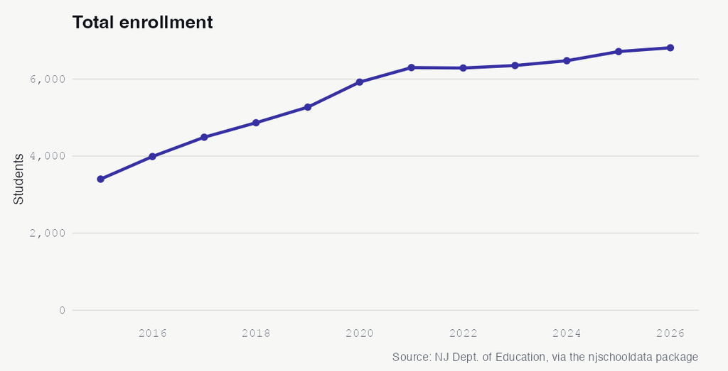

See the underlying data ›

No. 4 ATTENDANCE

## North Star’s Chronic Absenteeism Climbed From 17% Before COVID to a 28% Peak, Settling at 22% in 2024

More than one in five North Star students were chronically absent in 2024, still above the network’s pre-pandemic rate.

In 2024, 21.7% of North Star students were chronically absent, meaning they missed at least 10% of the school year. That is down from the pandemic peak but still above where the network started.

The trend traces a familiar arc. Chronic absence stood at 16.6% in 2019, surged to 22.0% in 2021 and a high of 27.6% in 2022 as schools navigated the return from remote learning, then eased to 24.2% in 2023 and 21.7% in 2024. Even after two straight years of improvement, the 2024 rate sat more than five points above the 2019 baseline.

Chronic absence is one of the strongest early warning signs in any school system, tied closely to test results and on-time graduation. Whether North Star can pull attendance back below its pre-COVID 16.6% is among the clearest near-term tests in the data.

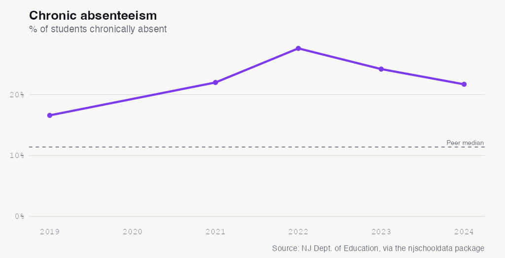

See the underlying data ›

No. 5 DEMOGRAPHICS

## North Star’s Hispanic Enrollment Share Quadrupled Since 2015 as Its Black Share Fell 9 Points

Between 2015 and 2026 the network’s Hispanic share rose from 3.4% to 15.9% while its Black share declined from 89.1% to 80.5%.

North Star remains a predominantly Black school, but its student mix has shifted measurably over a decade. In 2015, 89.1% of students were Black, 3.4% were Hispanic, and 5.0% were white. By 2026 the Black share had fallen to 80.5%, the Hispanic share had climbed to 15.9%, and the white share had dropped to 1.3%.

The Hispanic share saw the largest movement of any group — a gain of 12.5 percentage points, more than quadrupling — while the Black share fell 8.7 points and the white share fell 3.7 points. The change tracks broader demographic shifts in Newark, where the network draws nearly all of its students. (A few single-year figures in the data, such as 2018 and 2020, swing sharply and likely reflect reporting irregularities rather than real one-year reversals.)

The shift coincides with North Star’s rising multilingual-learner enrollment. As the Hispanic share grew, the question becomes how the network’s instruction and supports keep pace with a student body that looks different than it did when the school was half its current size.

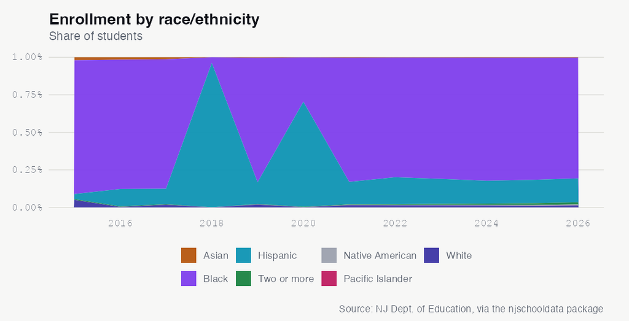

See the underlying data ›

No. 6 DEMOGRAPHICS

## North Star’s Multilingual Learner Count Grew From Zero to 327 in a Decade

Students classified as limited English proficient rose from none in 2015 to 327, or 4.8% of enrollment, in 2026.

When North Star enrolled 3,403 students in 2015, none were classified as limited English proficient. By 2026 the network counted 327 such students, or 4.8% of its enrollment — a population it built from scratch as it doubled in size.

The trend matters because, on the 2024 grade 3-8 English exam, multilingual learners posted some of the network’s lowest proficiency rates. The data raises a question it cannot resolve: how a network built around a college-prep model adapts its supports as its fastest-growing subgroup is also one of its hardest to serve.

See the underlying data ›

No. 7 EQUITY

## North Star Boys Graduated at 83% in 2025 While Girls Graduated at 93%, a 10-Point Gap

Among 2025 graduates, female students completed at 93.3% while male students completed at 82.8%.

North Star’s overall 88.3% graduation rate masks a sharp split by gender. Among the network’s 2025 cohort, 93.3% of female students graduated on time — from a cohort of 180 — while 82.8% of male students did, a gap of more than 10 percentage points.

Other subgroup rates clustered closer to the overall figure. Black students graduated at 88.8% from a cohort of 312, students who are economically disadvantaged at 88.5%, and Hispanic students at 85.7% from a smaller cohort of 35. Students with disabilities graduated at 81.6%, the lowest reported rate among the network’s subgroups, from a cohort of 49.

The pattern of girls outpacing boys and students with disabilities trailing is common across New Jersey, but the size of North Star’s gender gap stands out. The data leaves open why the network’s young men complete at a rate more than 10 points below their female classmates.

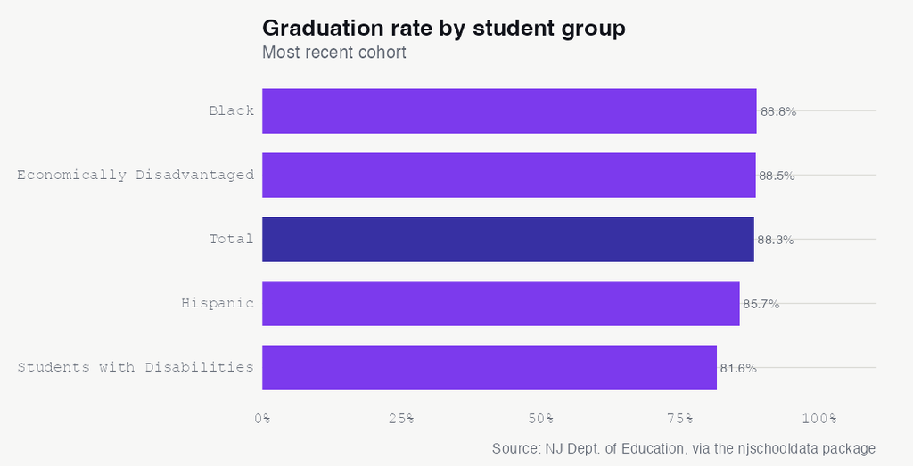

See the underlying data ›

No. 8 GRADUATION

## North Star’s Graduation Rate Has Never Topped 89% Even as Senior Cohorts Grew From 258 to 350

Across six cohorts the network’s four-year graduation rate moved between 81.8% and 88.3%, never reaching the 90s.

North Star’s college-prep reputation rests on tested achievement, but its four-year graduation rate tells a steadier, more modest story. The network graduated 88.3% of its 2025 senior cohort of 350 students — its highest mark in the data, yet still short of 90%.

The rate has held within a narrow band. Over six cohorts it ranged from a low of 81.8% in 2022 to the current 88.3%, dipping and recovering without a clear upward break, even as the graduating class grew from 258 students in 2020 to 350 in 2025. Meanwhile the network’s tested results — from AP pass rates to NJGPA English proficiency near 87% — run at or above state levels, a contrast suggesting the ceiling is less about academic preparation than about getting every enrolled senior across the finish line on time.

With cohorts still expanding, the question is whether North Star can finally lift on-time completion into the 90s while its senior classes keep growing.

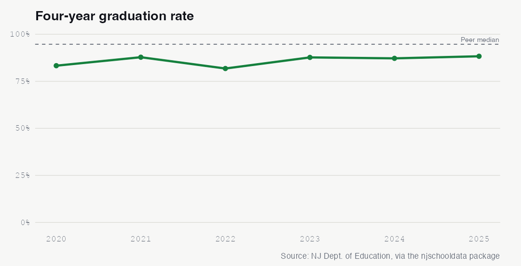

See the underlying data ›

No. 9 ACHIEVEMENT

## North Star Tests 87% Proficient in High-School English But 62% in Math

On the 2025 NJGPA, 86.9% of North Star students met the English bar while 62.3% met the math bar — a 24-point gap.

North Star’s high schoolers cleared the state’s English proficiency bar at a high rate in 2025: 86.9% scored proficient or above on the NJGPA English exam, up from 84.6% in 2023. Math told a different story, with 62.3% proficient or above — a gap of roughly 24 percentage points between the two subjects.

The math result has held remarkably flat. Across three years the share proficient moved only narrowly, from 62.2% in 2023 to 64.5% in 2024 to 62.3% in 2025, even as English climbed. That high-school math plateau echoes the network’s grade 3-8 results, where math proficiency has stalled in the high 40s since the pandemic — suggesting a math challenge that runs the length of the system rather than a single grade band.

For a network that sends nearly half its students to passing AP or IB scores, the persistent math gap on the state graduation assessment is a puzzle the numbers surface but do not explain.

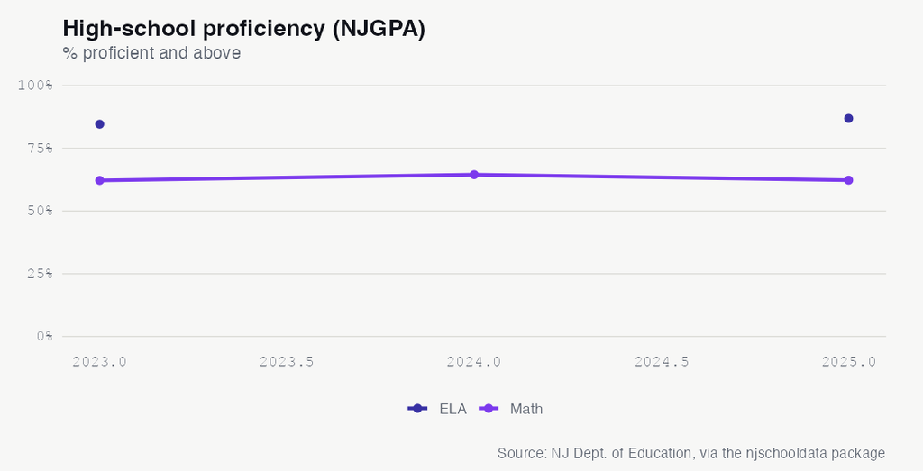

See the underlying data ›

No. 10 COLLEGE READINESS

## Nearly Half of North Star Students Pass an AP or IB Exam at a School Where 86% Qualify for Subsidized Lunch

In 2024, 45.9% of North Star students scored 3+ on an AP exam or 4+ on an IB exam, against a statewide rate of 23.0%.

At a school where 86.1% of students qualified for free or reduced-price lunch in 2026, the advanced-coursework numbers stand out. In 2024, 45.9% of North Star students earned a passing score — a 3 or higher on an Advanced Placement exam, or a 4 or higher on an International Baccalaureate exam — against a statewide figure of 23.0%.

The result is not a one-year spike. North Star’s share of students passing an AP or IB exam topped the state every year in the data, ranging from 30.5% in 2021 to a high of 54.6% in 2020. Participation is broad as well: 82% of students took AP or IB coursework in 2024, and 80.7% sat for an exam.

That strength sits uneasily beside the network’s stalled NJSLA math results and its four-year graduation rate stuck below 90%. The open question is which signal better predicts how North Star’s students fare after they leave: the college-level exams nearly half of them pass, or the on-time completion rate that has yet to reach its peers.

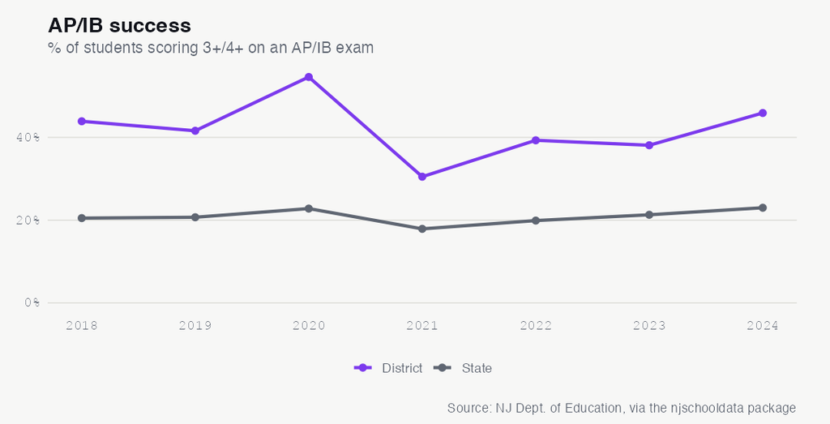

See the underlying data ›

## The Almanac

The full longitudinal record behind the stories above. Every number a reader can check.

### Enrollment (total)

| year | students | yoy | yoy_pct |
| --- | --- | --- | --- |
| 2015 | 3403 | NA | NA |
| 2016 | 3989 | 586 | 17.2 |
| 2017 | 4490 | 501 | 12.6 |
| 2018 | 4866 | 376 | 8.4 |
| 2019 | 5271 | 405 | 8.3 |
| 2020 | 5921 | 650 | 12.3 |
| 2021 | 6298 | 377 | 6.4 |
| 2022 | 6287 | -11 | -0.2 |
| 2023 | 6352 | 65 | 1 |
| 2024 | 6476 | 124 | 2 |
| 2025 | 6714 | 238 | 3.7 |
| 2026 | 6812 | 98 | 1.5 |

### Demographic share (%) by year

| end_year | white | black | hispanic | asian | native_american | pacific_islander | multiracial |
| --- | --- | --- | --- | --- | --- | --- | --- |
| 2015 | 5 | 89.1 | 3.4 | 2 | 0 | 0 | 0.5 |
| 2016 | 0.3 | 86.2 | 11.6 | 1.6 | 0 | 0 | 0.4 |
| 2017 | 1.7 | 86.3 | 10.2 | 1.3 | 0 | 0 | 0.4 |
| 2018 | 0 | 3.9 | 96.1 | 0 | 0 | 0 | 0 |
| 2019 | 1.9 | 82.9 | 14.5 | 0.4 | 0.1 | 0 | 0.2 |
| 2020 | 0.1 | 29.6 | 69.9 | 0.1 | 0 | 0 | 0.3 |
| 2021 | 1.5 | 82.8 | 14.9 | 0.2 | 0.2 | 0 | 0.4 |
| 2022 | 1.4 | 79.8 | 17.9 | 0.2 | 0.2 | 0 | 0.6 |
| 2023 | 1.3 | 80.8 | 16.6 | 0.2 | 0.2 | 0 | 0.8 |
| 2024 | 1.3 | 82.1 | 15.2 | 0.2 | 0.3 | 0 | 1 |
| 2025 | 1 | 81.4 | 15.6 | 0.3 | 0.4 | 0 | 1.2 |
| 2026 | 1.3 | 80.5 | 15.9 | 0.2 | 0.6 | 0.1 | 1.4 |

### Special populations (LEP, FRL)

| end_year | subgroup | students | pct |
| --- | --- | --- | --- |
| 2015 | lep | 0 | 0.0 |
| 2015 | free_reduced_lunch | 2856 | 83.9 |
| 2016 | lep | 18 | 0.5 |
| 2016 | free_reduced_lunch | 3457 | 86.7 |
| 2017 | lep | 55 | 1.2 |
| 2017 | free_reduced_lunch | 3901 | 86.9 |
| 2018 | lep | 57 | 1.2 |
| 2018 | free_reduced_lunch | 4166 | 85.6 |
| 2019 | lep | 41 | 0.8 |
| 2019 | free_reduced_lunch | 4568 | 86.7 |
| 2020 | lep | 71 | 1.2 |
| 2020 | free_reduced_lunch | 5116 | 86.4 |
| 2021 | lep | 101 | 1.6 |
| 2021 | free_reduced_lunch | 5423 | 86.1 |
| 2022 | lep | 94 | 1.5 |
| 2022 | free_reduced_lunch | 5375 | 85.5 |
| 2023 | lep | 121 | 1.9 |
| 2023 | free_reduced_lunch | 5310 | 83.6 |
| 2024 | lep | 181 | 2.8 |
| 2024 | free_reduced_lunch | 5485 | 84.7 |
| 2025 | lep | 255 | 3.8 |
| 2025 | free_reduced_lunch | 5821 | 86.7 |
| 2026 | lep | 327 | 4.8 |
| 2026 | free_reduced_lunch | 5865 | 86.1 |

### Graduation rate 4yr (total)

| year | grad_rate | cohort |
| --- | --- | --- |
| 2020 | 83.3 | 258 |
| 2021 | 87.8 | 304 |
| 2022 | 81.8 | 296 |
| 2023 | 87.7 | 324 |
| 2024 | 87.2 | 359 |
| 2025 | 88.3 | 350 |

### Graduation by subgroup (2025)

| subgroup | grad_rate | cohort |
| --- | --- | --- |
| female | 93.3 | 180 |
| black | 88.8 | 312 |
| economically disadvantaged | 88.5 | 330 |
| total | 88.3 | 350 |
| hispanic | 85.7 | 35 |
| male | 82.8 | NA |
| students with disabilities | 81.6 | 49 |
| american indian | NA | NA |
| asian | NA | NA |
| migrant students | NA | NA |
| military-connected students | NA | NA |
| multilingual learners | NA | NA |
| non-binary/undesignated gender | NA | NA |
| students experiencing homelessness | NA | NA |
| students in foster care | NA | NA |
| multiracial | NA | NA |
| white | NA | NA |

### NJGPA high-school proficiency (% proficient+)

| year | test | prof_above | valid |
| --- | --- | --- | --- |
| 2023 | ela | 84.6 | 350 |
| 2023 | math | 62.2 | 349 |
| 2024 | ela | NA | NA |
| 2024 | math | 64.5 | 352 |
| 2025 | ela | 86.9 | 367 |
| 2025 | math | 62.3 | 374 |

### NJGPA ELA by subgroup (2025)

| subgroup | prof |
| --- | --- |
| RACE/ETHNICITY | 87.8 |
| SUBGROUP | 87.0 |
| TOTAL | 86.9 |
| SUBGROUP | 86.4 |
| GENDER | 81.9 |
| RACE/ETHNICITY | 80.0 |
| SUBGROUP | 67.3 |
| SUBGROUP | 61.1 |

### NJSLA grades 3-8 proficiency (% proficient+, enrollment-weighted across grades)

| testing_year | test_name | prof |
| --- | --- | --- |
| 2017 | ela | 77.9 |
| 2017 | math | 65.4 |
| 2018 | math | 70.3 |
| 2019 | ela | 78.5 |
| 2019 | math | 71.1 |
| 2022 | ela | 64.0 |
| 2022 | math | 45.0 |
| 2023 | ela | 66.9 |
| 2023 | math | 46.5 |
| 2024 | ela | 66.2 |
| 2024 | math | 47.4 |

### NJSLA ELA proficiency by subgroup (2024, grades 3-8)

| subgroup | prof |
| --- | --- |
| white | 80.0 |
| non_ed | 71.6 |
| female | 71.3 |
| black | 67.5 |
| total_population | 66.2 |
| ed | 65.3 |
| hispanic | 59.8 |
| male | 59.0 |
| other | 53.9 |
| lep_current_former | 34.2 |
| sped_accomodations | 27.8 |
| special_education | 21.7 |
| MULTILINGUAL LEARNERS | 18.2 |
| CURRENT - ML | NA |
| lep_current | NA |

### Chronic absenteeism (% chronically absent)

| year | chronic_pct |
| --- | --- |
| 2019 | 16.6 |
| 2021 | 22 |
| 2022 | 27.6 |
| 2023 | 24.2 |
| 2024 | 21.7 |

### Disciplinary removals

[output not shown]

### Police notifications (incident counts)

| year | violence | weapons | vandalism | substances | hib | other |
| --- | --- | --- | --- | --- | --- | --- |
| 2019 | 0 | 0 | 0 | 0 | 0 | 0 |
| 2020 | 0 | 0 | 0 | 0 | 0 | 0 |
| 2021 | 0 | 0 | 0 | 0 | 0 | 0 |
| 2022 | 2 | 1 | 0 | 0 | 1 | 0 |
| 2023 | 2 | 0 | 1 | 0 | 0 | 5 |
| 2024 | 3 | 0 | 0 | 0 | 0 | 5 |

### HIB (harassment/intimidation/bullying) investigations

| end_year | alleged | confirmed |
| --- | --- | --- |
| 2019 | 1 | 2 |
| 2020 | 15 | 0 |
| 2021 | 0 | 0 |
| 2022 | 11 | 11 |
| 2023 | 19 | 7 |
| 2024 | 2 | 4 |

### SAT participation (% of grade)

| year | sat_part | state_sat |
| --- | --- | --- |
| 2018 | 100 | 72.2 |
| 2019 | 100 | 72.1 |
| 2020 | 100 | 71.1 |
| 2021 | 100 | 45.4 |
| 2022 | 100 | 60.8 |
| 2023 | 100 | 61.9 |
| 2024 | 100 | 62.7 |

### AP/IB & dual enrollment (% of students)

| year | apib_coursework | apib_exam | ap3_ib4 | state_ap3_ib4 | dual |
| --- | --- | --- | --- | --- | --- |
| 2018 | 85.6 | 73.4 | 43.9 | 20.5 | 0 |
| 2019 | 87.7 | 72.5 | 41.6 | 20.7 | 0 |
| 2020 | 83.3 | 77.5 | 54.6 | 22.8 | 0 |
| 2021 | 86.6 | 76.8 | 30.5 | 17.9 | 0 |
| 2022 | 84.4 | 81 | 39.3 | 19.9 | 0 |
| 2023 | 86 | 79.9 | 38.1 | 21.3 | 0 |
| 2024 | 82 | 80.7 | 45.9 | 23 | 0 |

### Special education (raw rows; inspect for classification rate)

| end_year | district_id |
| --- | --- |
| 2024 | 7320 |

### Staffing ratios

| end_year | student_teacher_district | student_admin_district | student_counselor_district | student_nurse_district |
| --- | --- | --- | --- | --- |
| 2024 | 25:1 | 712:1 | 6404:1 | 3202:1 |

Back to top